# Red Wine Quality Dataset Exploration by Khaled Almanea

This tidy data set contains 1,599 red wines with 11 variables on the chemical properties of the wine. At least 3 wine experts rated the quality of each wine, providing a rating between 0 (very bad) and 10 (very excellent).

# Univariate Plots Section

```
##        X          fixed.acidity   volatile.acidity  citric.acid
##  Min.   :   1.0   Min.   : 4.60   Min.   :0.1200   Min.   :0.000
##  1st Qu.: 400.5   1st Qu.: 7.10   1st Qu.:0.3900   1st Qu.:0.090
##  Median : 800.0   Median : 7.90   Median :0.5200   Median :0.260
##  Mean   : 800.0   Mean   : 8.32   Mean   :0.5278   Mean   :0.271
##  3rd Qu.:1199.5   3rd Qu.: 9.20   3rd Qu.:0.6400   3rd Qu.:0.420
##  Max.   :1599.0   Max.   :15.90   Max.   :1.5800   Max.   :1.000
##  residual.sugar     chlorides       free.sulfur.dioxide
##  Min.   : 0.900   Min.   :0.01200   Min.   : 1.00
##  1st Qu.: 1.900   1st Qu.:0.07000   1st Qu.: 7.00
##  Median : 2.200   Median :0.07900   Median :14.00
##  Mean   : 2.539   Mean   :0.08747   Mean   :15.87
##  3rd Qu.: 2.600   3rd Qu.:0.09000   3rd Qu.:21.00
##  Max.   :15.500   Max.   :0.61100   Max.   :72.00
##  total.sulfur.dioxide    density             pH          sulphates
##  Min.   :  6.00       Min.   :0.9901   Min.   :2.740   Min.   :0.3300
##  1st Qu.: 22.00       1st Qu.:0.9956   1st Qu.:3.210   1st Qu.:0.5500
##  Median : 38.00       Median :0.9968   Median :3.310   Median :0.6200
##  Mean   : 46.47       Mean   :0.9967   Mean   :3.311   Mean   :0.6581
##  3rd Qu.: 62.00       3rd Qu.:0.9978   3rd Qu.:3.400   3rd Qu.:0.7300
##  Max.   :289.00       Max.   :1.0037   Max.   :4.010   Max.   :2.0000
##     alcohol         quality
##  Min.   : 8.40   Min.   :3.000
##  1st Qu.: 9.50   1st Qu.:5.000
##  Median :10.20   Median :6.000
##  Mean   :10.42   Mean   :5.636
##  3rd Qu.:11.10   3rd Qu.:6.000
##  Max.   :14.90   Max.   :8.000
```

Our dataset consists of 13 variables, with almost 1,600 observations.

```
##   X fixed.acidity volatile.acidity citric.acid residual.sugar chlorides
## 1 1           7.4             0.70        0.00            1.9     0.076
## 2 2           7.8             0.88        0.00            2.6     0.098
## 3 3           7.8             0.76        0.04            2.3     0.092
## 4 4          11.2             0.28        0.56            1.9     0.075
## 5 5           7.4             0.70        0.00            1.9     0.076
## 6 6           7.4             0.66        0.00            1.8     0.075
##   free.sulfur.dioxide total.sulfur.dioxide density   pH sulphates alcohol
## 1                  11                   34  0.9978 3.51      0.56     9.4
## 2                  25                   67  0.9968 3.20      0.68     9.8
## 3                  15                   54  0.9970 3.26      0.65     9.8
## 4                  17                   60  0.9980 3.16      0.58     9.8
## 5                  11                   34  0.9978 3.51      0.56     9.4
## 6                  13                   40  0.9978 3.51      0.56     9.4
##   quality
## 1       5
## 2       5
## 3       5
## 4       6
## 5       5
## 6       5
```

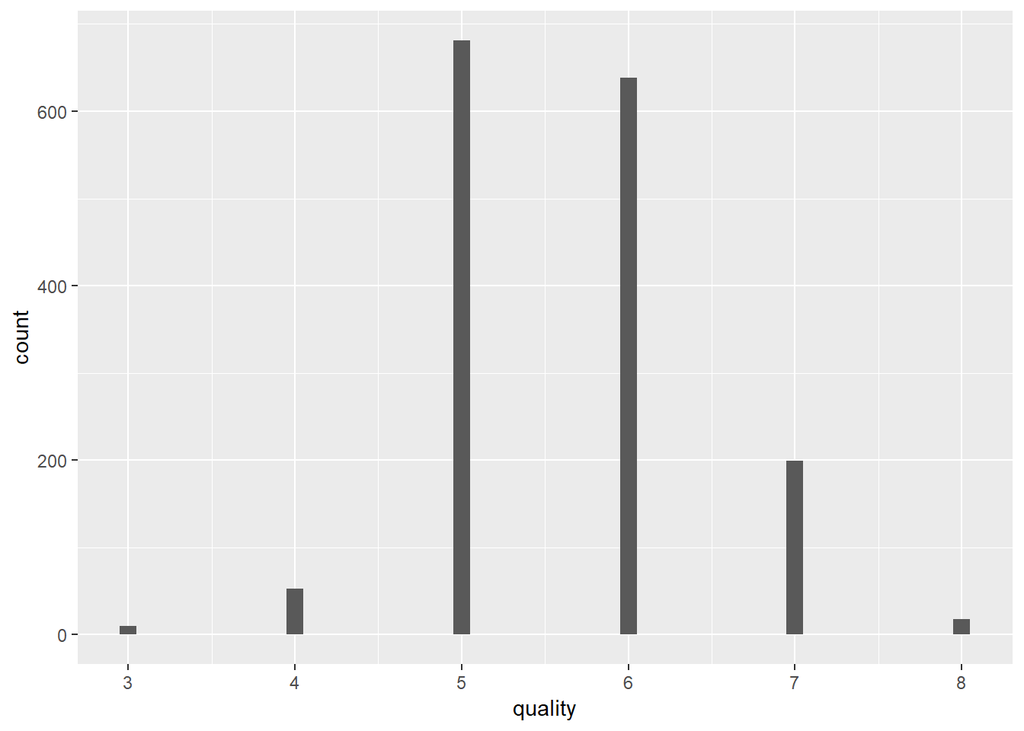

Most of the wine availabe in this sample has a quality between 5 and 6, with very few wins at 8 quality and almost 200 at 7, which ingrediant we should use to increase the quality of the 6s and 5s?

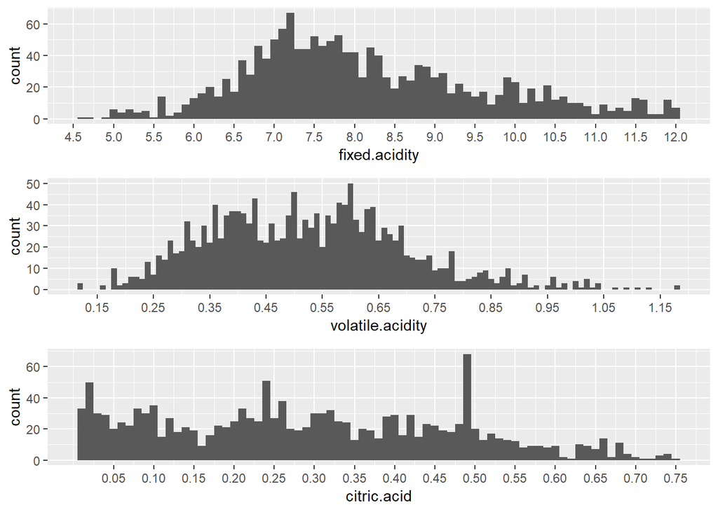

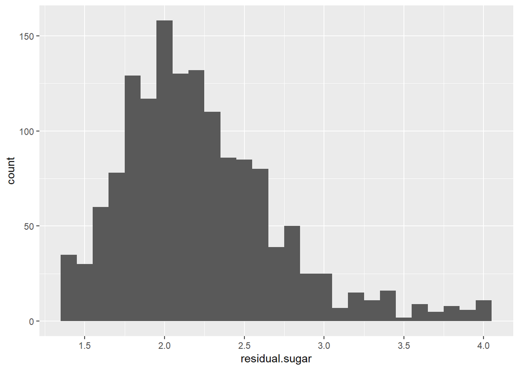

The plot shows the residual sugar data is skewed right with a peak between the 2 and 2.25.

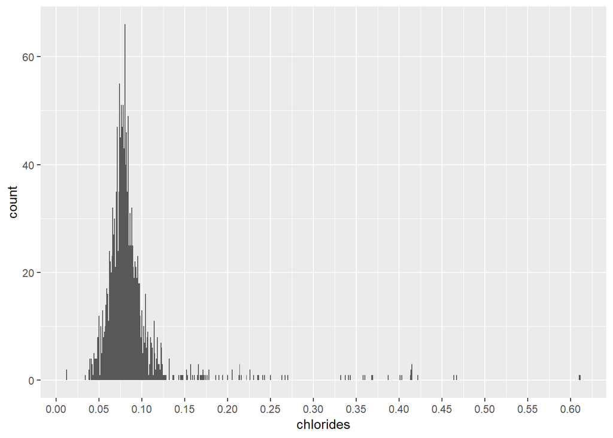

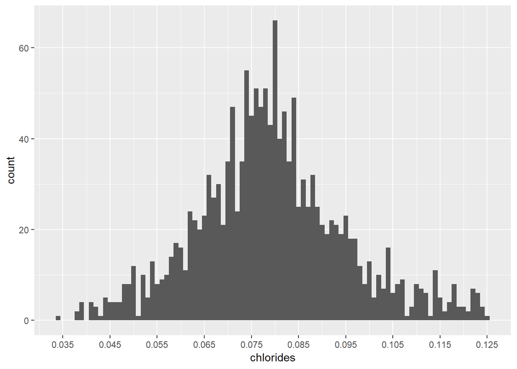

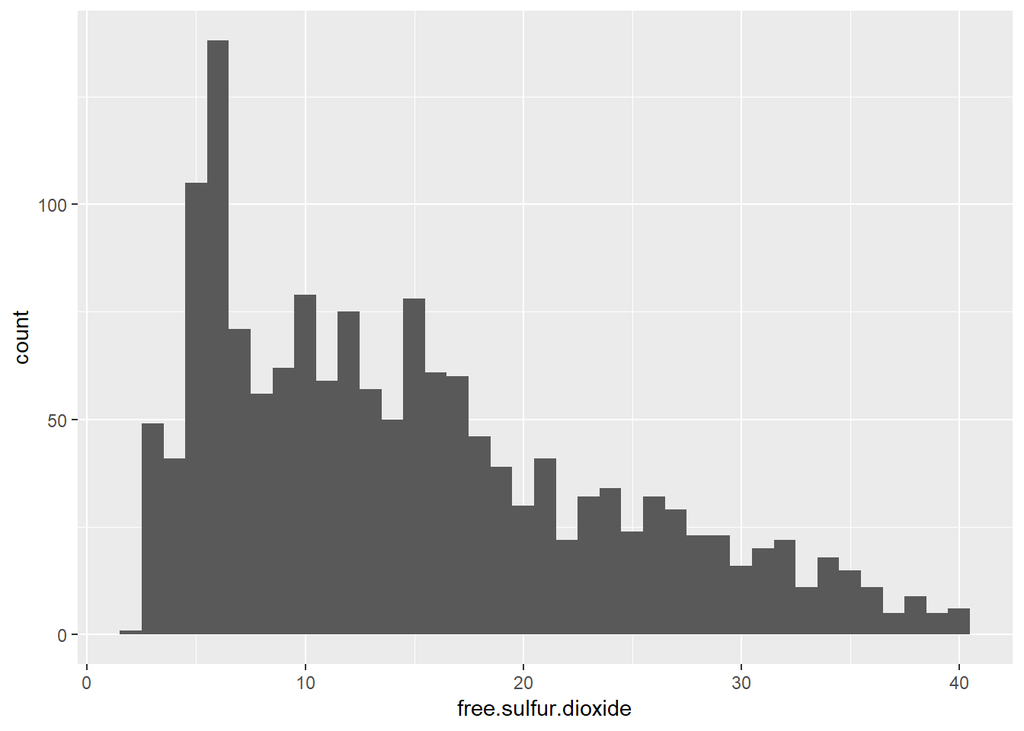

The plot shows the free sulfur dioxide data is skewed right with a peak between at 5.

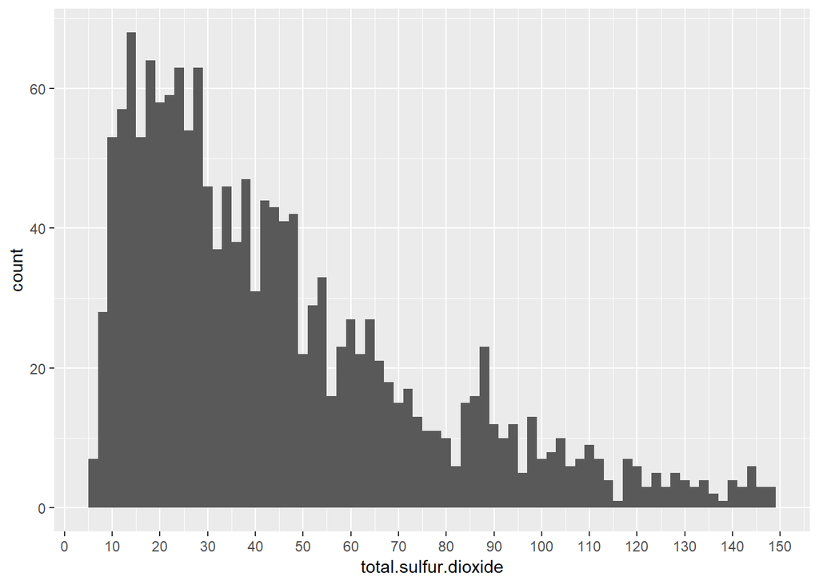

Also the total sulfur dioxide is skewed right with a peak between 10 and 30.

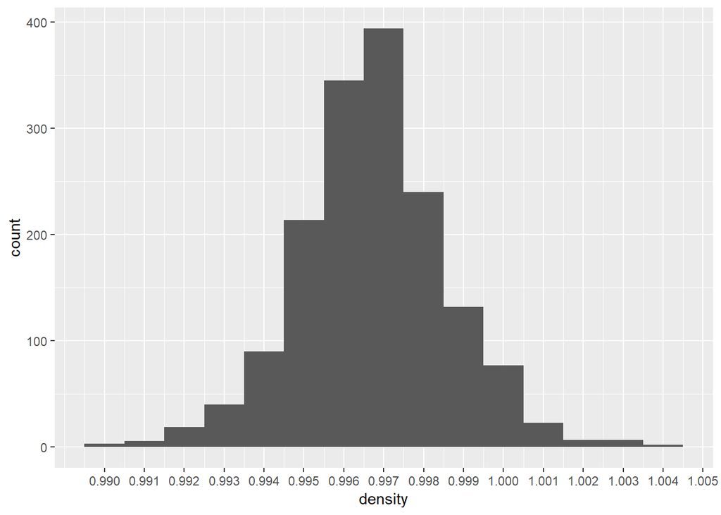

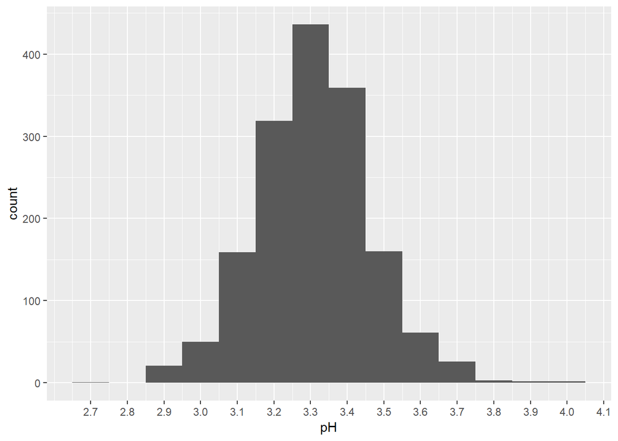

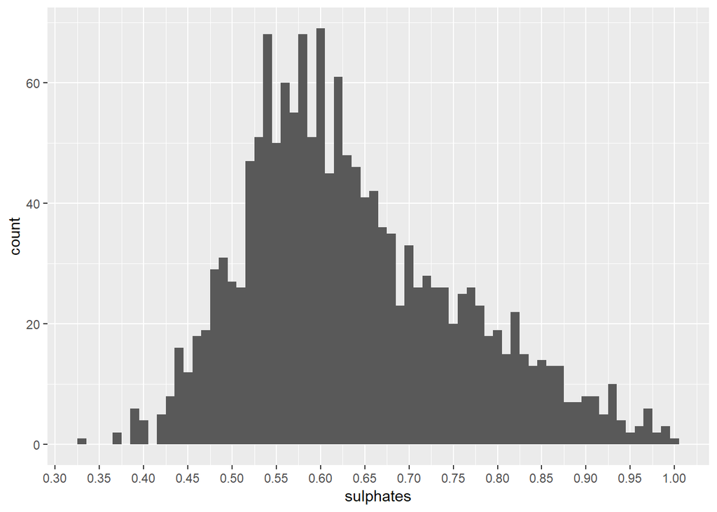

Density, PH and Sulphates has bell curved shape or data is normally distrbuted with data peaks as follows:  
1- Density: between 0.9955 and 0.9975.  
2- PH: between 3.3 and 3.4.  
3- Sulphates: between 0.52 and 0.6.

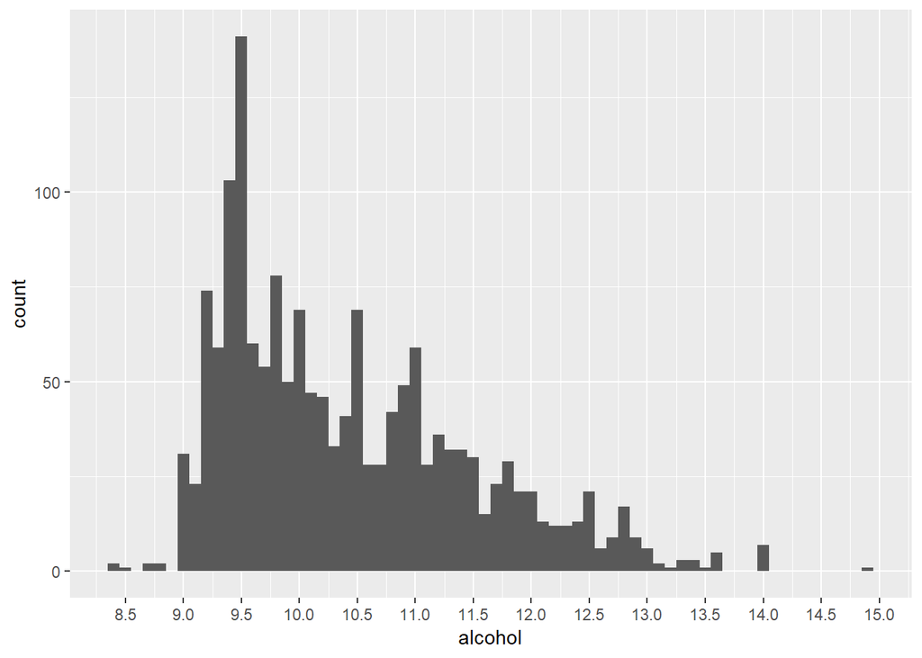

The plot shows the alcohol data is skewed right with a peak between at 9.5.

# Univariate Analysis

### What is the structure of your dataset?

There are 1,599 observation in the dataset with 12 features (fixed acidity, volatile acidity, citric acid, residual sugar, chlorides, free sulfur dioxide, total sulfur dioxide, density, PH, sulphates, alcohol and quality). all variables are nominal continuous except quality it is nominal discrete and range between (3 to 8).

Other observations:  
Most wines quality in the sample is between 5 and 6.  
Most wines in the sample has a PH level between 3.3 and 3.4.  
Max alcohol value is 14.9, mean is 10.42.

### What is/are the main feature(s) of interest in your dataset?

What I need to know from this dataset is the affect of all red wine ingrediants to make the best wine, I will also look deeply these varialbes acidity, PH and alcohol because these are what I hear people mention when they talk about wine without ofcurce ignoring the rest of the chemical.

### What other features in the dataset do you think will help support your investigation into your feature(s) of interest?

I need to see the relationships of all valriables, maybe all of them support my investigation.

### Did you create any new variables from existing variables in the dataset?

Yes, I added rating column from quality to make the exoploration of the relations between quality and other variables more conveniant.

```r
# create red_wine_subset for later use in the correlation
red_wine_subset <- red_wine[, c(2:13)]
# change quality to ordered factor
red_wine$quality <- factor(red_wine$quality, ordered = TRUE)

# create quality rating variable
red_wine$rating <- ifelse(red_wine$quality < 5, 'bad', ifelse(
  red_wine$quality < 7, 'average', 'good'))
red_wine$rating <- ordered(red_wine$rating,
                     levels = c('bad', 'average', 'good'))
```

### Of the features you investigated, were there any unusual distributions? Did you perform any operations on the data to tidy, adjust, or change the form of the data? If so, why did you do this?

Just subsetted most of the variables when making the graphs to read the graphs clearly.

# Bivariate Plots Section

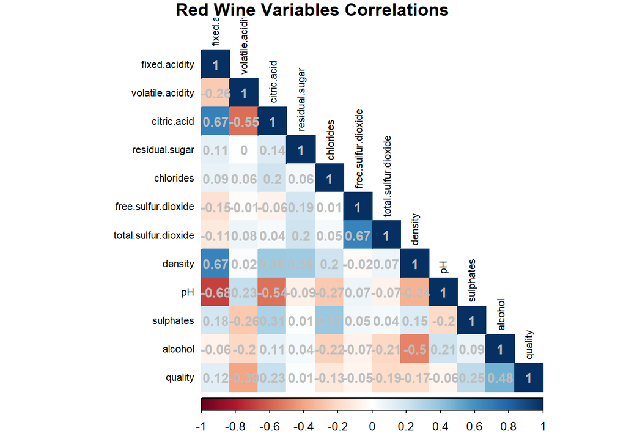

The fixed acidity and the citric acid corrolate positivly with each other and negativly with the PH level. also it seems that we have a negative relationship between density and alcohol level plus a 0.48 positive corrolation between quality and alcohol.

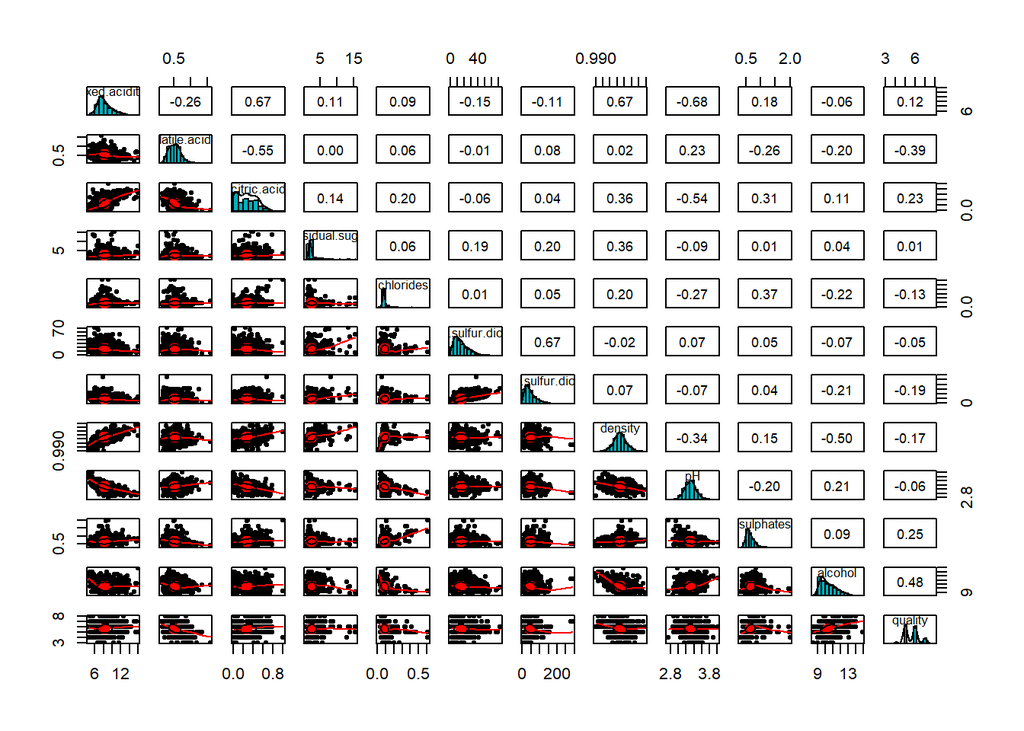

Based on the LM red lines above it seems some of the relationships needs more exploration like for example the residual sugar with the density it looks like there is a relationship that is not clear because of outlied values affect on the relationship, other relations that need to be explored:  
- volatile acidity with quality  
- residual sugar with free sulfur dioxide  
- residual sugar with alcohol (this might be true because in the fermentation process the yeast feeds onto the suger and produce alcohol)  
- chlorids with sulphates  
- Density with PH  
- Density with Alcohol  
- sulphates with quality - citric acid with quality

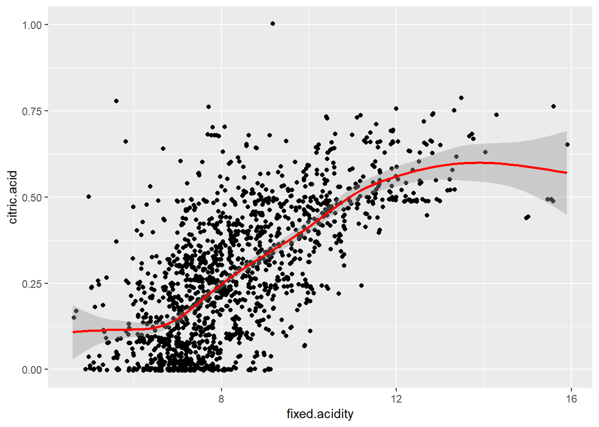

The corrolation between citric acid and fixed acidity is strong and positive.

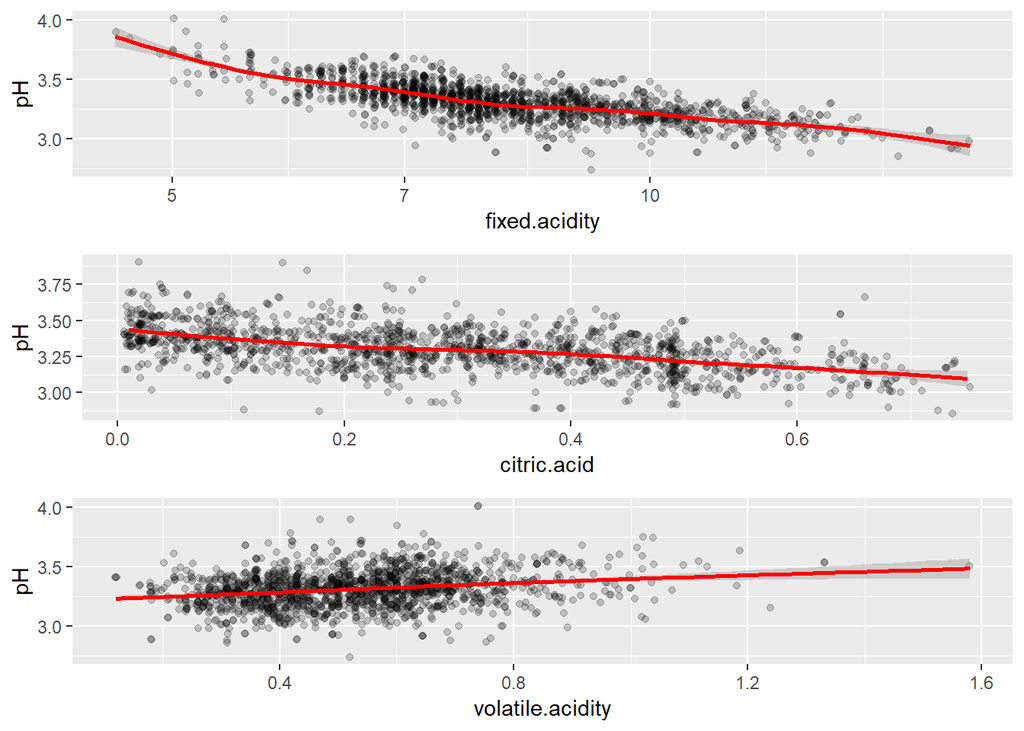

It is clear that pH has a negative relationship with both fixed acidity and citric acid and has a positive relationship with volatile acidity.

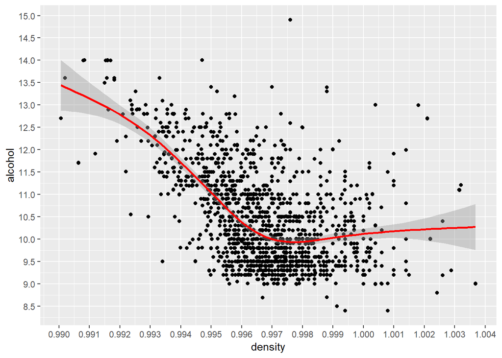

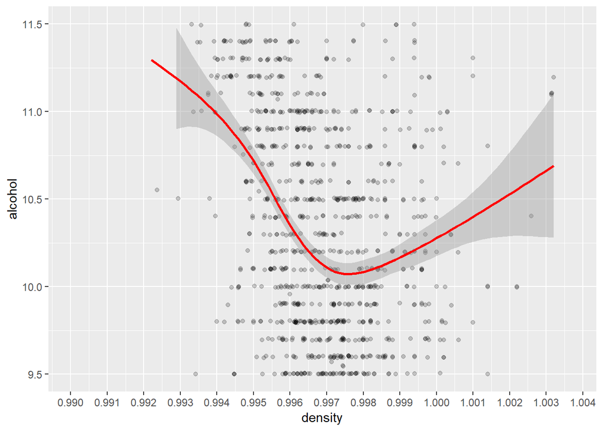

```
##    Min. 1st Qu.  Median    Mean 3rd Qu.    Max.
##    8.40    9.50   10.20   10.42   11.10   14.90
```

```
##    Min. 1st Qu.  Median    Mean 3rd Qu.    Max.
##  0.9901  0.9956  0.9968  0.9967  0.9978  1.0037
```

It seems the relation is moderate between alcohol and density.

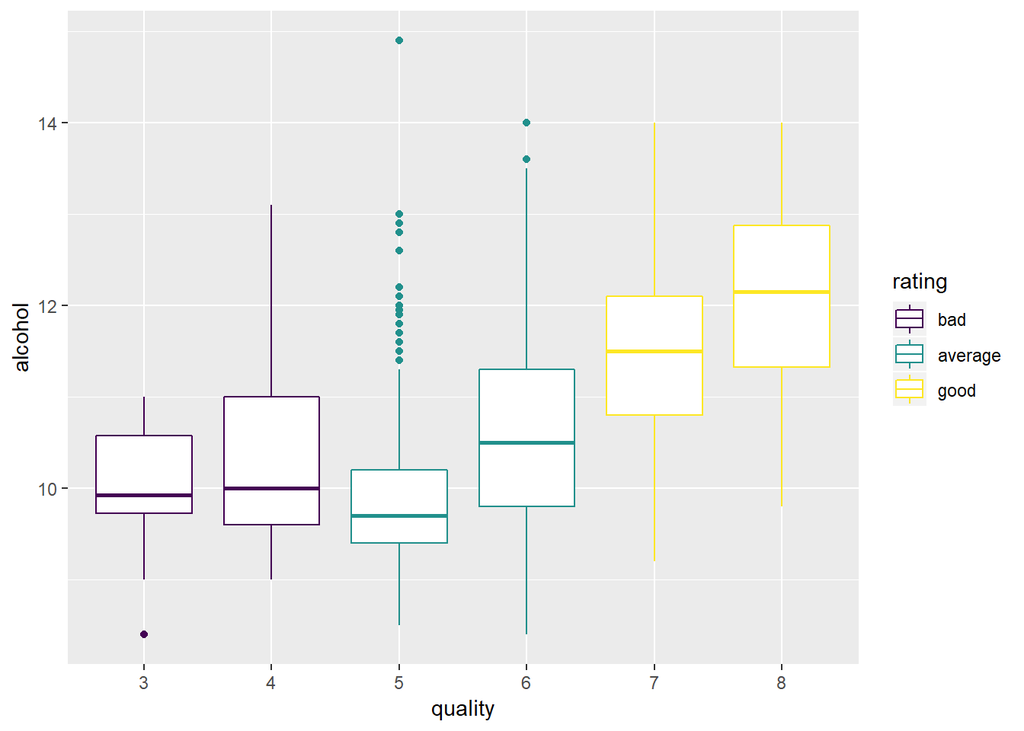

As per the above plot the quality increases at moderate rates with higher alcohol.

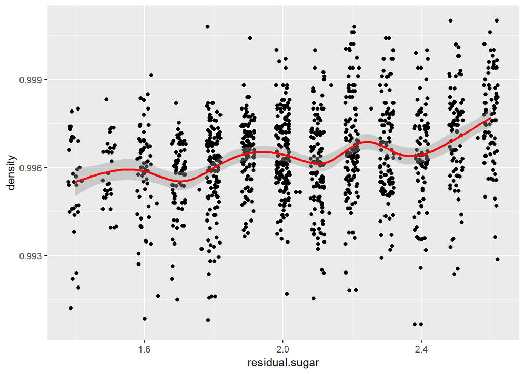

```
##    Min. 1st Qu.  Median    Mean 3rd Qu.    Max.
##   0.900   1.900   2.200   2.539   2.600  15.500
```

There is a weak positive relation between residual sugar and density.

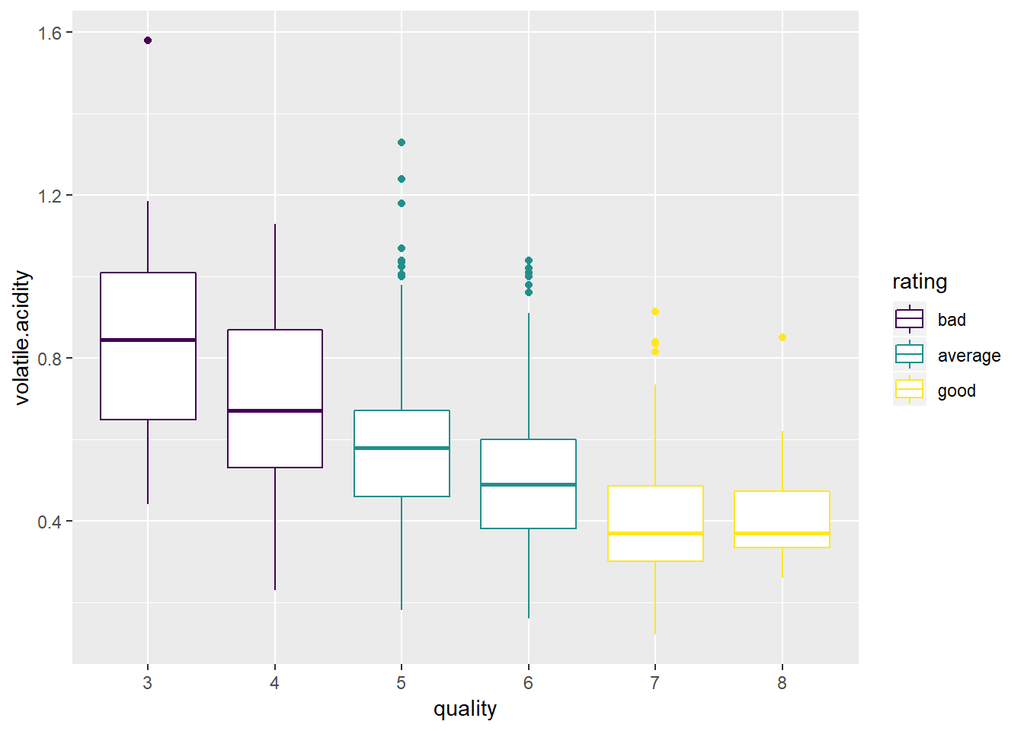

Volatile acid and quality have a -0.39 moderate negative correlation, which says red wine quality decreases if volatile acidity increases.

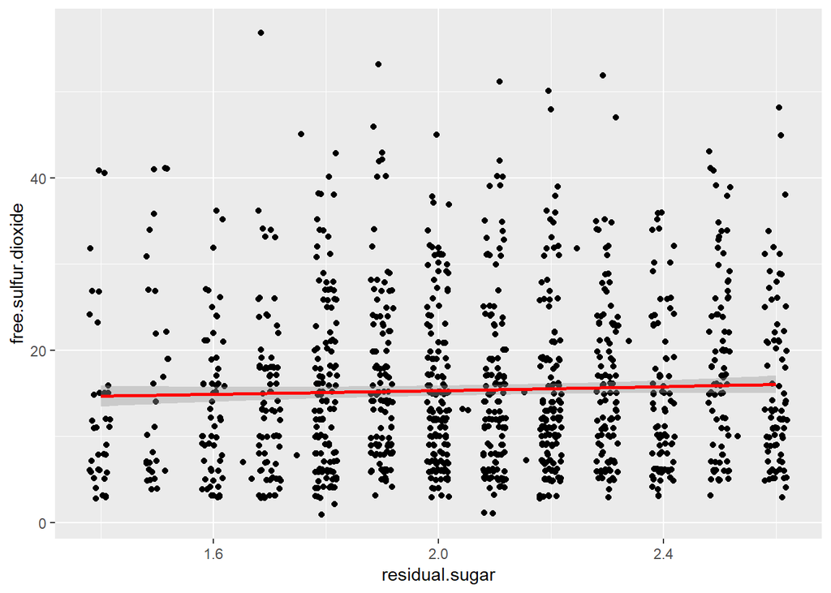

Relationship between residual sugar and free sulfur dioxide is weak, and I felt there is a relation before moving the outliers values from the residual sugar which were making the relation looks positive.

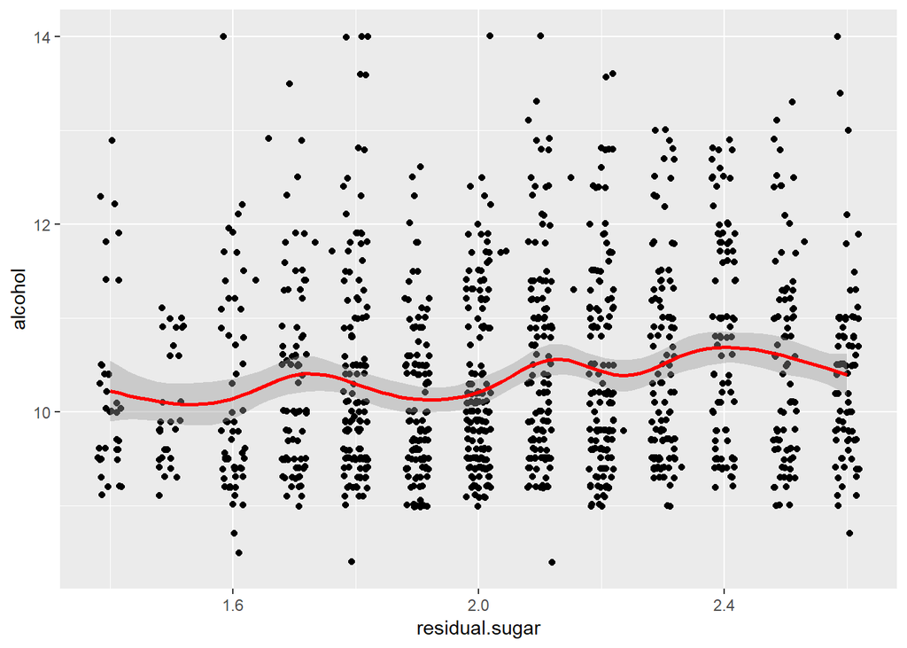

without the outliers

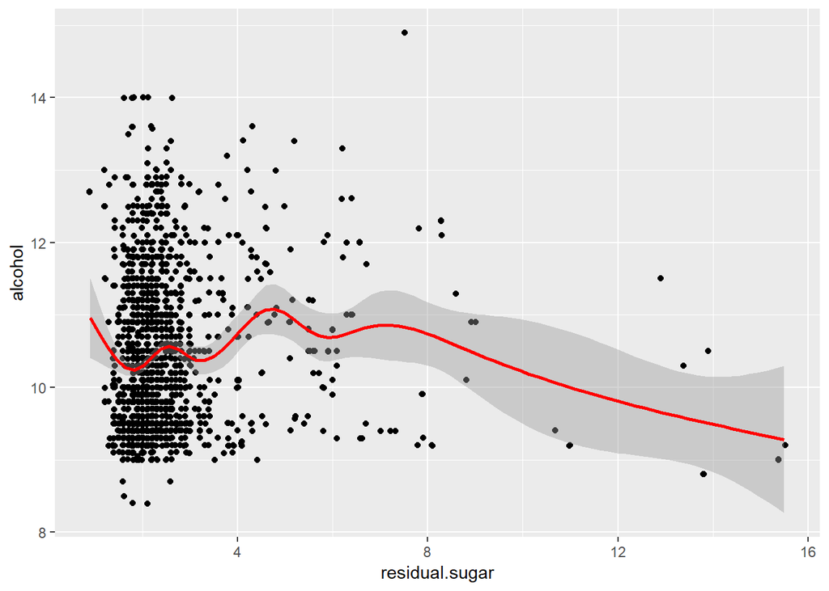

Both variable correlate at a 0.04 which is very low but in the fermentation process the yeast feeds onto the suger and produce alcohol which means if the grapes had low sugar level and the yeast finish up the sugar before finishing the process we will end up with low alcohol level. and what I see from the above drawing there is more than 0.04 relation but it is complicated relation.

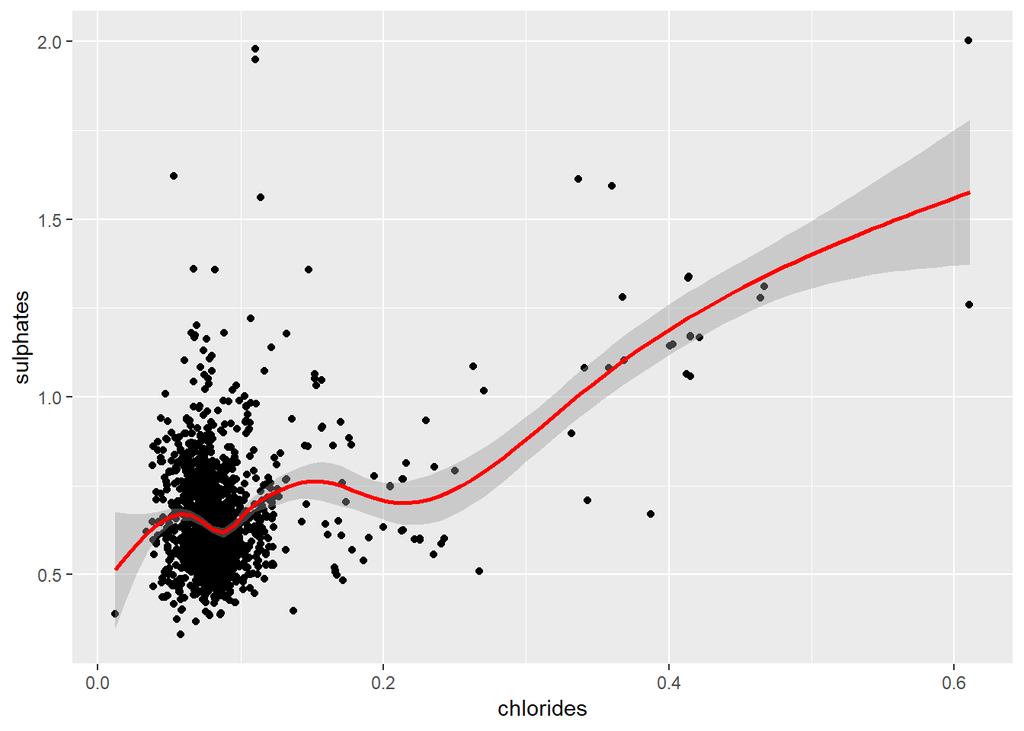

```
##    Min. 1st Qu.  Median    Mean 3rd Qu.    Max.
## 0.01200 0.07000 0.07900 0.08747 0.09000 0.61100
```

```
##    Min. 1st Qu.  Median    Mean 3rd Qu.    Max.
##  0.3300  0.5500  0.6200  0.6581  0.7300  2.0000
```

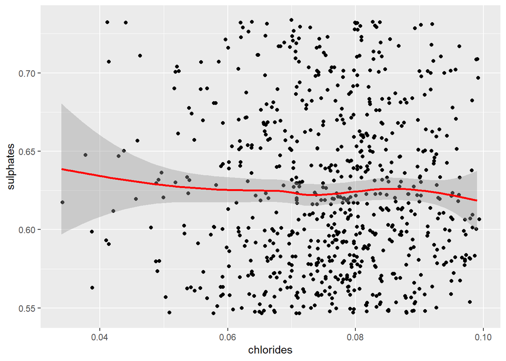

The relationship between sulphates and chlorides looks weak.

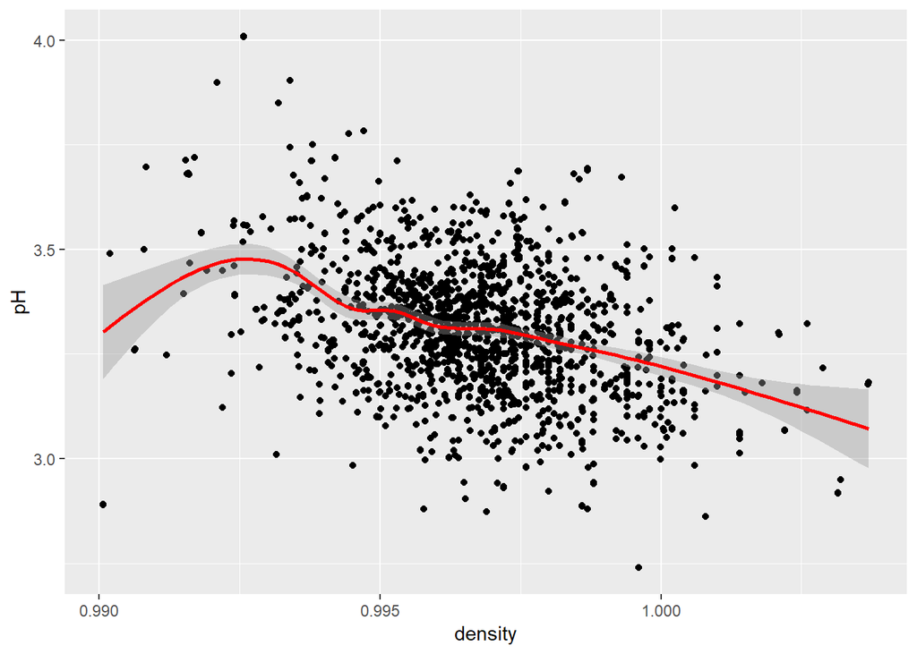

correlation is at moderate negative level of -0.34.

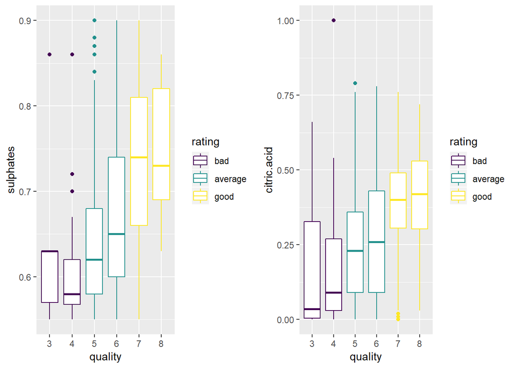

There is a weak positive correlations for both “quality and sulphates” and “quality and citric acid”. Quality trends in the same direction as both sulphates and citric acid at a weak rate.

# Bivariate Analysis

### Talk about some of the relationships you observed in this part of the investigation. How did the feature(s) of interest vary with other features in the dataset?

The main feature(s) of interest were pH, acidity variables, alcohol and quality.

Acidity:

fixed acidity and citric acid have a strong and positive correlation and they have negtive relation with pH level which is used to measure the acidity level in liqueds.

pH:

pH has a weak positive relationship with volatile acidity which has a -0.39 moderate negative correlation, which says red wine quality decreases if volatile acidity increases.

Alcohol:

Alcohol has a moderate negative relationship with density and moderate positive relationship with quality.

Quality:

quality increases at moderate rates with higher alcohol. Volatile acid and quality have a -0.39 moderate negative correlation, which says red wine quality decreases if volatile acidity increases. There is a weak positive correlations for both “quality and sulphates” and “quality and citric acid”. Quality trends in the same direction as both sulphates and citric acid at a weak rate.

### Did you observe any interesting relationships between the other features (not the main feature(s) of interest)?

Yes, there is some other correlations between the other features like:  
- There is a weak positive relation between residual sugar and density which might affect alcohol hence affect quality - Alcohol and residual sugar Both variable correlate at a 0.04 which is very low but in the fermentation process the yeast feeds onto the suger and produce alcohol which means if the grapes had low sugar level and the yeast finish up the sugar before finishing the process we will end up with low alcohol level. and what I see from the above drawing there is more than 0.04 relation but it is complicated relation.

### What was the strongest relationship you found?

# Multivariate Plots Section

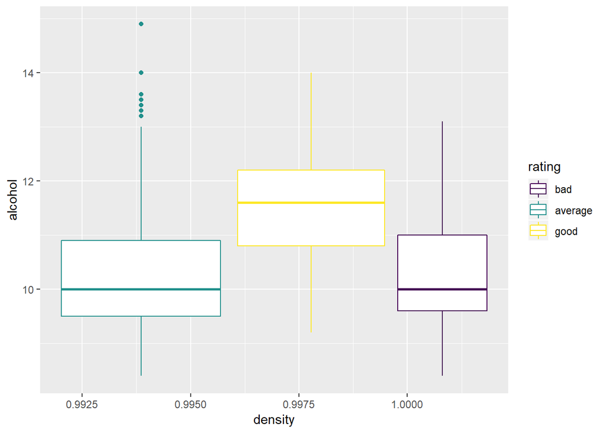

There is a negative moderate correlation of 0.5 between alcohol and density. This means higher alcohol implies lower density. This makes sense since alcohol is less dense than water. The boxplot confirms wines rated good have higher alcohol content.

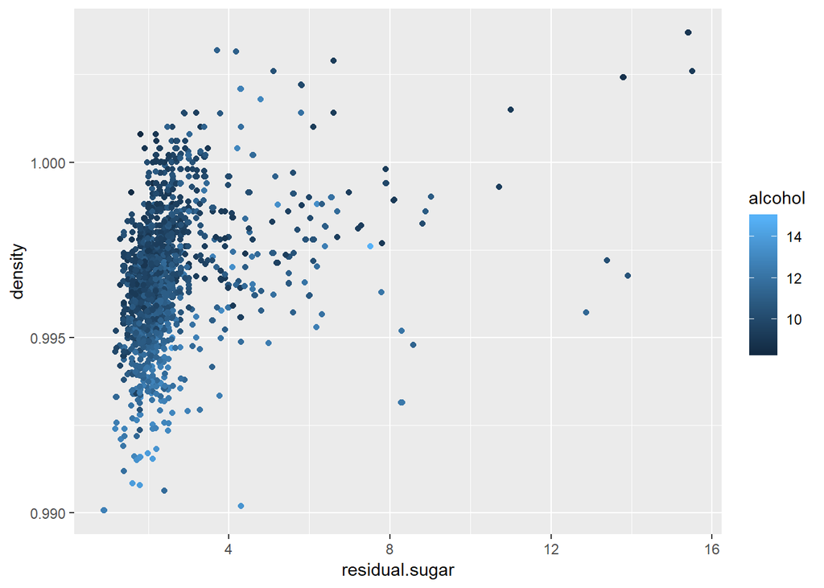

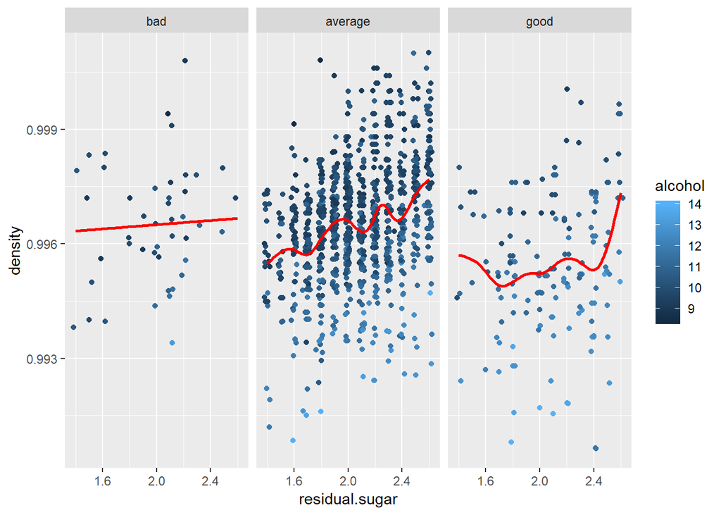

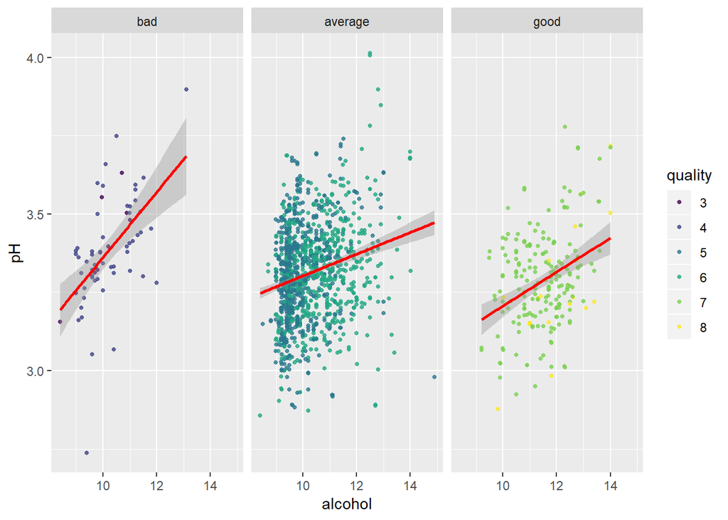

As per the above low pH and high Alcohol percentage seems to produce better wines.

## Linear Modelling:

```r
set.seed(1221)
training_data <- sample_frac(red_wine, .6)
test_data <- red_wine[ !red_wine$X %in% training_data$X, ]
m1 <- lm(as.numeric(quality) ~ alcohol, data = training_data)
m2 <- update(m1, ~ . + sulphates)
m3 <- update(m2, ~ . + volatile.acidity)
m4 <- update(m3, ~ . + citric.acid)
m5 <- update(m4, ~ . + fixed.acidity)
m6 <- update(m2, ~ . + pH)
mtable(m1,m2,m3,m4,m5,m6)
```

```
##
## Calls:
## m1: lm(formula = as.numeric(quality) ~ alcohol, data = training_data)
## m2: lm(formula = as.numeric(quality) ~ alcohol + sulphates, data = training_data)
## m3: lm(formula = as.numeric(quality) ~ alcohol + sulphates + volatile.acidity,
##     data = training_data)
## m4: lm(formula = as.numeric(quality) ~ alcohol + sulphates + volatile.acidity +
##     citric.acid, data = training_data)
## m5: lm(formula = as.numeric(quality) ~ alcohol + sulphates + volatile.acidity +
##     citric.acid + fixed.acidity, data = training_data)
## m6: lm(formula = as.numeric(quality) ~ alcohol + sulphates + pH,
##     data = training_data)
##
## ====================================================================================================
##                          m1            m2           m3           m4           m5           m6
## ----------------------------------------------------------------------------------------------------
##   (Intercept)           0.155        -0.273        0.866***     0.973***     0.497        1.494**
##                        (0.220)       (0.224)      (0.247)      (0.254)      (0.287)      (0.515)
##   alcohol               0.333***      0.320***     0.286***     0.284***     0.296***     0.339***
##                        (0.021)       (0.021)      (0.020)      (0.020)      (0.020)      (0.021)
##   sulphates                           0.855***     0.599***     0.650***     0.667***     0.733***
##                                      (0.126)      (0.124)      (0.127)      (0.126)      (0.129)
##   volatile.acidity                                -1.153***    -1.279***    -1.352***
##                                                   (0.124)      (0.143)      (0.144)
##   citric.acid                                                  -0.231       -0.629***
##                                                                (0.132)      (0.174)
##   fixed.acidity                                                              0.058***
##                                                                             (0.017)
##   pH                                                                                     -0.569***
##                                                                                          (0.149)
## ----------------------------------------------------------------------------------------------------
##   R-squared             0.209         0.245        0.308        0.310        0.319        0.256
##   adj. R-squared        0.208         0.243        0.306        0.307        0.315        0.254
##   sigma                 0.707         0.691        0.662        0.661        0.657        0.686
##   F                   252.335       155.125      141.769      107.317       89.264      109.700
##   p                     0.000         0.000        0.000        0.000        0.000        0.000
##   Log-likelihood    -1027.549     -1004.996     -963.139     -961.610     -955.575     -997.782
##   Deviance            478.652       456.660      418.487      417.154      411.937      449.841
##   AIC                2061.098      2017.992     1936.279     1935.219     1925.150     2005.565
##   BIC                2075.695      2037.456     1960.608     1964.415     1959.211     2029.894
##   N                   959           959          959          959          959          959
## ====================================================================================================
```

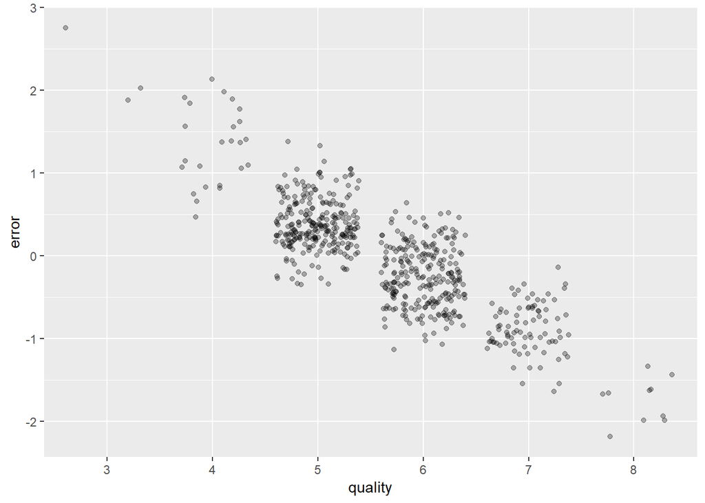

# Multivariate Analysis

### Talk about some of the relationships you observed in this part of the investigation. Were there features that strengthened each other in terms of looking at your feature(s) of interest?

- higher alcohol implies lower density and better quality.
- it seems that it is possible to increase alcohol level by increasing sugar level in the fermentation process.

### Were there any interesting or surprising interactions between features?

The relationship between residual sugar and alcohol.

### OPTIONAL: Did you create any models with your dataset? Discuss the strengths and limitations of your model.

Because of the low R squared value this indicates that changes in the predictors are not related to changes in the response variable. alcohol contributes to only 22% of the Wine Quality and the most of the factors converged on the Average quality wines, This can be due to the fact that our dataset comprised mainly of ‘Average’ quality wines and as there were very few data about the ‘Good’ and the ‘Bad’ quality wines in the training dataset.

# Final Plots and Summary

### Plot One

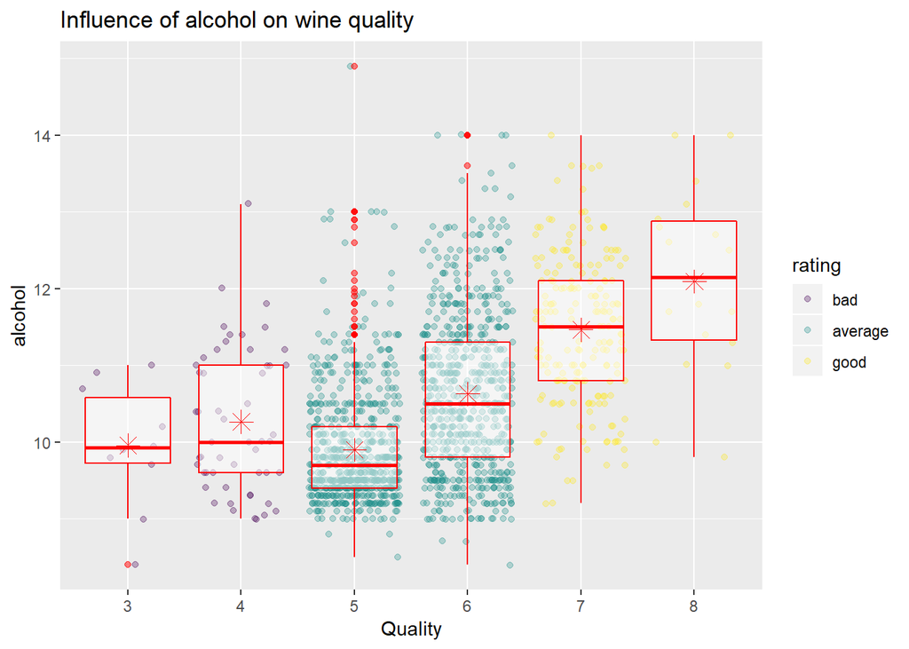

### Description One

From the above figure we can see that mean starts to synchronize with the median from level 5 of quality whcih tell us that data is normally distributed. the high median in the best quality tells us that best quality wines have higher alcohol levels.

### Plot Two

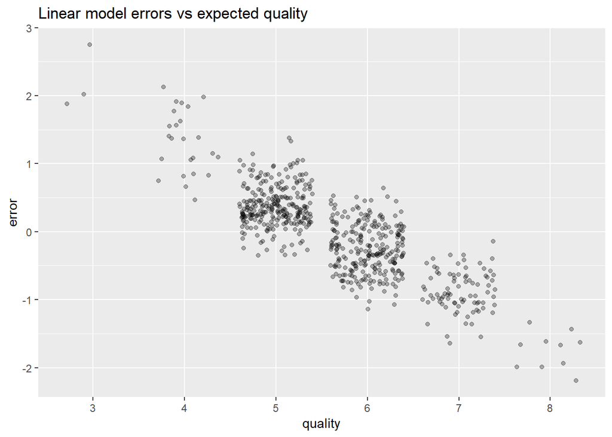

### Description Two

We see that the error is much more dense in the ‘Average’ quality section than the ‘Good’ and the ‘Bad’ quality wines. This is evident from the fact that most of our dataset contains ‘Average’ quality wines and there is not too many data in the extreme ranges. The linear model with the R squared value for m5 could only explain around 33% change in quality. Also the earlier models clearly shows that due to the lack of information, it is not the best model to predict both ‘Good’ and ‘Bad’ quality wines.

### Plot Three

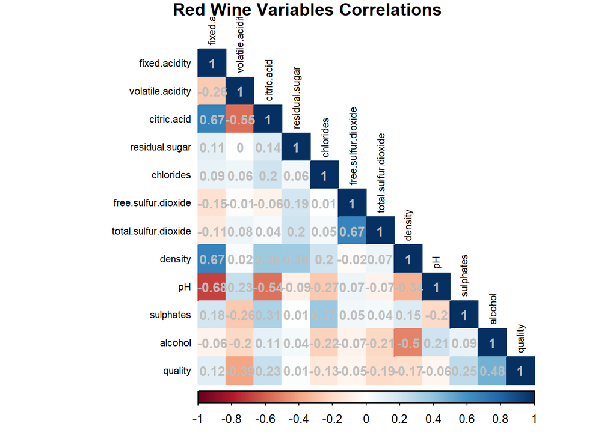

### Description Three

The correlation matrix make it easier to identify the strong and medium relations from the begging of the analysis.

# Reflection

With this exploratory data analysis on the red wine dataset, my main challenge was to know what was each component in the wine where wine is not in our culture so it is a new thing to me, but what aid me to go through it was internet research about these component plus looking at the visuals of the individual component and their correlation.